# DS202 Homework 5: Eli Musgrove

### #1

```r
# Libraries
suppressWarnings(suppressMessages(library(readr)))
suppressWarnings(suppressMessages(library(tidyverse)))
suppressWarnings(suppressMessages(library(lubridate)))
suppressWarnings(suppressMessages(library(ggrepel)))
suppressWarnings(suppressMessages(library(readxl)))

# Import data
liquor = suppressMessages(read_csv('2019_Iowa_Liquor_Sales.csv'))
```

### #2

```r
# Extract latitude and longitude
liquor$`Store Location` = gsub("[^0-9.-]", " ", liquor$`Store Location`)
liquor$`Store Location` = trimws(liquor$`Store Location`)
liquor = liquor %>% separate(`Store Location`, into=c('latitude', 'longitude'), remove=FALSE, sep=" ", convert=TRUE)

# Convert columns to proper type
liquor$`Vendor Number` = as.numeric(liquor$`Vendor Number`)
liquor$`Invoice/Item Number` = as.numeric(gsub("[^0-9]", "", liquor$`Invoice/Item Number`))
liquor$Date = mdy(liquor$Date)

# Extract year, month, day from Date
liquor$Month = month(liquor$Date)
liquor$Day = day(liquor$Date)
liquor$Year = year(liquor$Date)
```

### #3

##### 3a. There are obvious clumps of stores in areas like campustown and north/south Ames. There are also regions where no stores that sell alcohol are located - these are likely residential-only zoned areas.

##### 3b. Vodka is the most popular which makes sense because of how cheap and standard it is. It surprised me that Canadian whiskey would be 2nd place after standard vodka though. Because Ames is a college town, there are very few sophisticated/expensive drinks and it is mostly focused on hard alcohol which also makes sense.

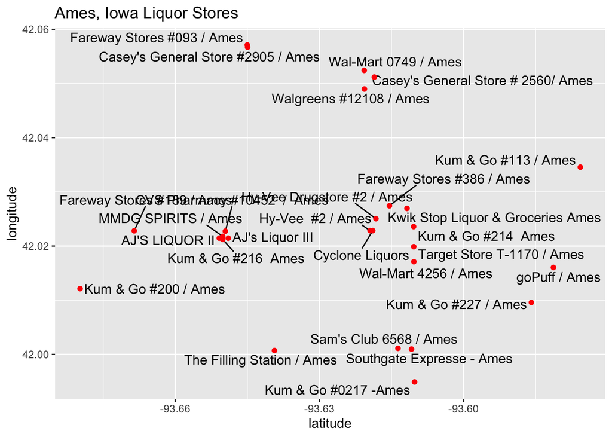

```r
# 3a
liquor %>% distinct(`Store Name`, .keep_all=TRUE) %>% ggplot(aes(x=latitude, y=longitude, label=`Store Name`)) + geom_text_repel() + geom_point(color='red', position='jitter') + ggtitle('Ames, Iowa Liquor Stores')
```

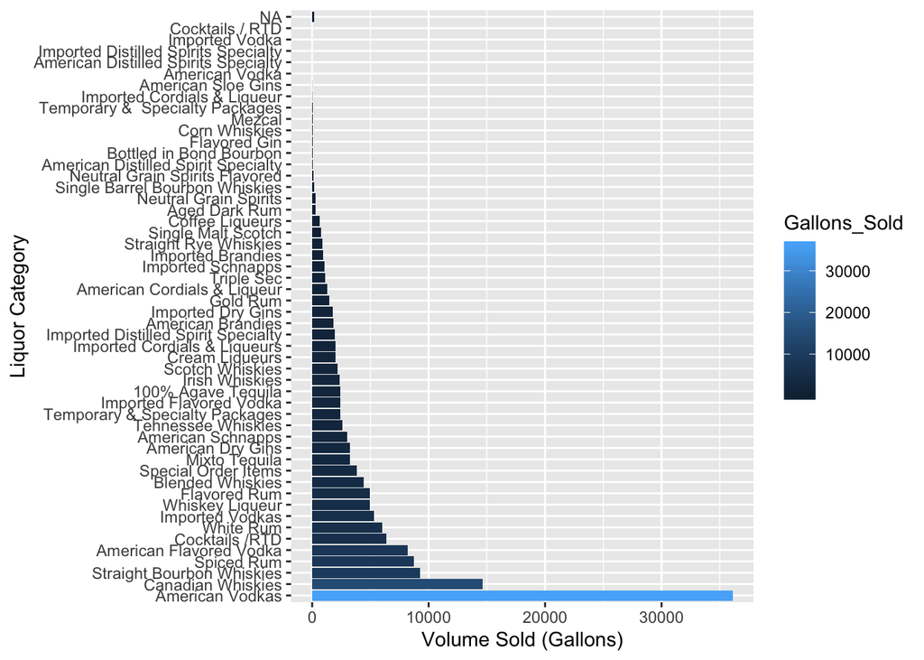

```r
# 3b
liquor %>% group_by(`Category Name`) %>% summarize(Gallons_Sold = sum(`Volume Sold (Gallons)`)) %>% select(`Category Name`, Gallons_Sold) %>% ggplot(aes(x=reorder(`Category Name`, -Gallons_Sold), y=Gallons_Sold, fill=Gallons_Sold)) + geom_bar(stat="identity") + coord_flip() + xlab('Liquor Category') + ylab('Volume Sold (Gallons)')
```